# Визуализация биомедицинских данных. Домашнее задание

# Как выполнить и сдать

В домашнем задании вы продолжите работать с данными `hogwarts`. Этот файл лежит в папке задания вместе с данными (`data`) и картинками к заданиям (`images`); файл есть и в Google Классе. Решения пишите прямо здесь, в `homework_viz_2026.qmd`: под каждым заданием оставлен пустой чанк.

1. Откройте папку задания в Positron (`File → Open Folder`). Проект — это и есть открытая папка, R работает из её корня.
2. Файл задания лежит в корне этой папки, рядом с `data` и `images`. Если вы скачали его отдельно из Google Класса, положите его туда же.
3. Все пути — относительные, от корня проекта: `data/hogwarts_2026.csv`, `images/task_2_4.png`. Путей вида `C:/Users/…` в работе быть не должно.
4. Отрендерите файл в HTML: кнопкой Preview в Positron или в терминале командой `quarto render homework_viz_2026.qmd`. Рядом появится `homework_viz_2026.html`.
5. Загрузите `.qmd` и `.html` на свой GitHub, в папку `basic_datavis_hw_2026`.
6. Чтобы сдать задание, приложите ссылку на GitHub в Google Классе.

В этом задании почти соблюдаются принципы классицизма: одно задание — не меньше одного графика и не меньше одного чанка, если не сказано иное. Правило действует, даже когда задание просит вернуться к предыдущему графику. При этом вы всегда можете расширить интерпретацию или показать то же самое ещё и другим, более подходящим, на ваш взгляд, способом — дополнительными графиками к заданию. Некоторые пункты касаются того, о чём на занятиях прямо не говорили, и потребуют справки и документации; обычно такие места оговорены в условии явно.

Если возникнут трудности технического, коммуникативного или иного характера, пишите в общий чат в Telegram или в личные сообщения: [@EvaMariaShelley](https://t.me/EvaMariaShelley) (Ева) и [@dj_djenny](https://t.me/dj_djenny) (Диана).

# Правила для всех заданий

Выполняйте их, даже если в тексте задания они не упомянуты.

- Под каждым графиком напишите интерпретацию: что на нём видно и какой вывод из этого следует, в 2–4 предложениях. Перечисление геомов и цветов интерпретацией не считается. Если вывода нет или данных для него мало, так и напишите.
- Делайте текст на графике настолько крупным, насколько позволяют сам график и ваше чувство меры. Читаемые надписи — важный (но не так уж часто встречающийся) элемент графиков.
- Не используйте фон ggplot2 по умолчанию.
- У каждого графика должен быть заголовок, отражающий его суть, и правильно названные оси.
- Все подписи на графиках — на русском языке.
- Старайтесь, чтобы графики были достаточно крупными и читались не только в отрендеренном HTML, но и при интерактивном запуске чанков в Positron.
- Однотипные графики стройте функцией (конспект 2, раздел «П6 · Функция для однотипных графиков (слайд П6)»).
- Цвета факультетов — как в конспектах: Гриффиндор `#B32025`, Хаффлпафф `#D7A900`, Рейвенкло `#2E5EAA`, Слизерин `#2F7D4A`. В задании 10 цвета берите с образца.

Для некоторых заданий понадобится пакет patchwork: он собирает несколько графиков в один (конспект 2, раздел «П9 · Несколько графиков на одну страницу (слайд П9)»). Советуем почитать его документацию и пользоваться им в домашней работе. Для задания 8 нужен пакет gghighlight. Если каких-то пакетов нет, установите их один раз в консоли: `install.packages(c("patchwork", "gghighlight"))`.

Если, пока вы строите и интерпретируете график, у вас появилась гипотеза, не стесняйтесь её проверить: постройте для того же задания ещё один график (или несколько), проведите дополнительное исследование.

# Подготовка

```r
library(tidyverse)
library(patchwork)
library(gghighlight)

hogwarts <- read_csv("data/hogwarts_2026.csv", show_col_types = FALSE)
```

# Задание 1

Постройте барплот (столбчатую диаграмму), отражающий распределение числа студентов по курсам обучения. Раскрасьте столбики любым понравившимся цветом: подойдёт и название цвета, и hex-код. Задайте и цвет контура столбиков. Проинтерпретируйте график.

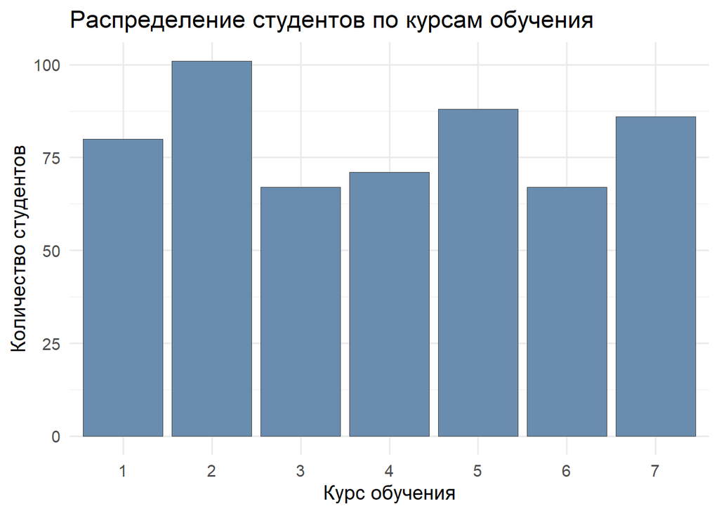

```r
ggplot(hogwarts, aes(x = factor(course))) +
  geom_bar(
    fill = "#6A8CAF",
    colour = "grey25",
    linewidth = 0.3
  ) +
  labs(
    title = "Распределение студентов по курсам обучения",
    x = "Курс обучения",
    y = "Количество студентов"
  ) +
  theme_minimal(base_size = 14)
```

**Интерпретация:** По данным датасета распределение студентов по курсам неравномерное. Больше всего студентов учится на втором курсе — 101 человек, меньше всего на третьем и шестом — по 67 человек. При этом резкого дисбаланса между курсами нет: численность каждой группы находится в диапазоне от 67 до 101 студента

# Задание 2

Постройте новый барплот, отражающий распределение числа студентов по факультетам. Добавьте на график вторую факторную переменную — происхождение (`bloodStatus`).

С помощью аргумента `position` измените график так, чтобы каждый столбец показывал распределение факультета по чистоте крови в долях. Запишите текстом в этом файле, какой вывод можно сделать из графика.

[figure not shown]

```r
ggplot(hogwarts, aes(x = house, fill = bloodStatus)) +
  geom_bar(position = "fill") +
  labs(
    title = "Распределение студентов по происхождению на факультетах",
    x = "Факультет",
    y = "Доля студентов",
    fill = "Происхождение"
  ) +
  scale_x_discrete(
    labels = c(
      Gryffindor = "Гриффиндор",
      Hufflepuff = "Пуффендуй",
      Ravenclaw = "Когтевран",
      Slytherin = "Слизерин"
    )
  ) +
  scale_fill_discrete(
    labels = c(
      "Полукровки",
      "Из семей маглов",
      "Чистокровные"
    )
  ) +
  theme_minimal(base_size = 18) +
  theme(
    plot.title = element_text(
      size = 20,
      face = "bold"
    )
  )
```

*Проверка количества и процентных долей студентов по происхождению на факультетах*

```r
hogwarts |>
  count(house, bloodStatus) |>
  group_by(house) |>
  mutate(share = n / sum(n) * 100)
```

```
# A tibble: 11 × 4
# Groups:   house [4]
   house      bloodStatus     n share
   <chr>      <chr>       <int> <dbl>
 1 Gryffindor half-blood     95 64.6
 2 Gryffindor muggle-born    29 19.7
 3 Gryffindor pure-blood     23 15.6
 4 Hufflepuff half-blood    110 73.3
 5 Hufflepuff muggle-born    13  8.67
 6 Hufflepuff pure-blood     27 18
 7 Ravenclaw  half-blood     97 69.3
 8 Ravenclaw  muggle-born    18 12.9
 9 Ravenclaw  pure-blood     25 17.9
10 Slytherin  half-blood     89 72.4
11 Slytherin  pure-blood     34 27.6
```

**Вывод:** На всех четырёх факультетах преобладают студенты-полукровки — их доля составляет от 64,6% до 73,3%. Наибольшая доля студентов из семей маглов наблюдается на Гриффиндоре (19,7%), а на Слизерине таких студентов нет. При этом на Слизерине наблюдается самая большая доля чистокровных студентов — 27,6%. В целом состав факультетов по происхождению различается, хотя на каждом из них большинство составляют полукровки

# Задание 3

Отобразите распределение баллов, заработанных студентами на 3-й неделе обучения, по факультетам. Постарайтесь показать одновременно и форму распределения, и некоторые описательные статистики. Отсортируйте факультеты в порядке убывания медианного балла за 3-ю неделю (функция, которую мы разбирали на слайде 21, по умолчанию сортирует именно по медиане, так что задавать медиану отдельным аргументом не нужно). Если используете `geom_jitter()`, постарайтесь, чтобы точки лежали кучнее вдоль оси, которая не отражает само распределение. Проинтерпретируйте график.

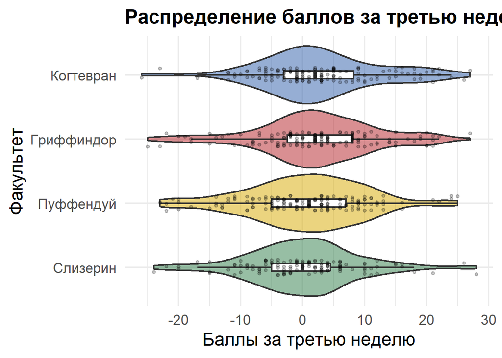

```r
hogwarts |>
  mutate(house = fct_reorder(house, week_3)) |>
  ggplot(aes(x = week_3, y = house)) +
  geom_violin(
    aes(fill = house),
    scale = "width",
    alpha = 0.5
  ) +
  geom_boxplot(
    width = 0.12,
    outliers = FALSE,
    fill = "white"
  ) +
  geom_jitter(
    width = 0,
    height = 0.12,
    alpha = 0.2,
    size = 1
  ) +
  scale_fill_manual(
    values = c(
      Gryffindor = "#B32025",
      Hufflepuff = "#D7A900",
      Ravenclaw = "#2E5EAA",
      Slytherin = "#2F7D4A"
    ),
    labels = c(
      Gryffindor = "Гриффиндор",
      Hufflepuff = "Пуффендуй",
      Ravenclaw = "Когтевран",
      Slytherin = "Слизерин"
    )
  ) +
  scale_y_discrete(
    labels = c(
      Gryffindor = "Гриффиндор",
      Hufflepuff = "Пуффендуй",
      Ravenclaw = "Когтевран",
      Slytherin = "Слизерин"
    )
  ) +
  labs(
    title = "Распределение баллов за третью неделю по факультетам",
    x = "Баллы за третью неделю",
    y = "Факультет",
    fill = "Факультет"
  ) +
  theme_minimal(base_size = 18) +
  theme(
    plot.title = element_text(size = 20, face = "bold"),
    legend.position = "none"
  )
```

**Интерпретация:** Медианные баллы за третью неделю самые высокие у Гриффиндора и Когтеврана — по 2 балла. У Пуффендуя медиана составляет 1 балл, а у Слизерина — 0 баллов. При этом разброс баллов на всех факультетах довольно большой, и значения у студентов сильно различаются

# Задание 4

Постройте гистограмму результатов любого экзамена на ваш выбор, кроме зельеварения. Настройте оптимальное, на ваш взгляд, число столбцов гистограммы. Выполните фасетирование по курсу. Постарайтесь, чтобы график был по возможности компактным. Проинтерпретируйте график.

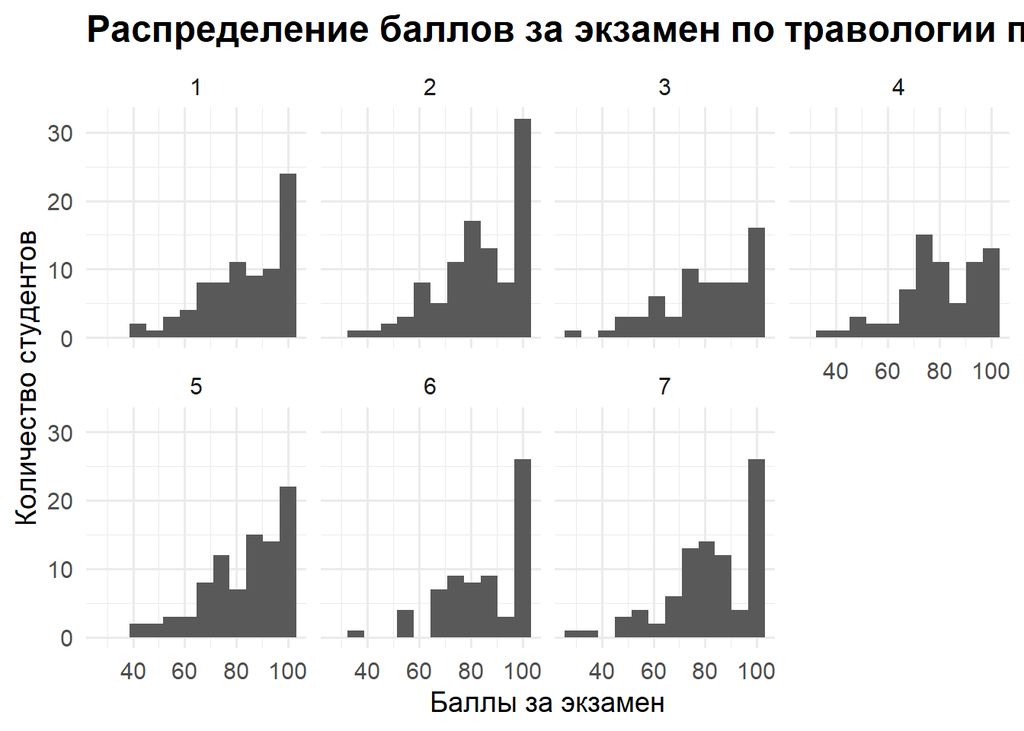

```r
ggplot(hogwarts, aes(x = `Herbology exam`)) +
  geom_histogram(bins = 12) +
  facet_wrap(vars(course), ncol = 4) +
  labs(
    title = "Распределение баллов за экзамен по травологии по курсам",
    x = "Баллы за экзамен",
    y = "Количество студентов"
  ) +
  theme_minimal(base_size = 14) +
  theme(
    plot.title = element_text(size = 18, face = "bold")
  )
```

**Интерпретация:** На всех курсах студенты в основном набрали высокие баллы за экзамен по травологии. Довольно много студентов получили максимальные 100 баллов. В целом результаты на разных курсах похожи, но на четвёртом курсе оценки немного ниже, а на шестом — выше

# Задание 5

Постройте скаттерплот, показывающий связь между суммарным баллом студента за год и оценкой за экзамен (по травологии, магловедению, нумерологии и зельеварению). Добавьте на график линию тренда. Удалите доверительную область и сделайте линию прямой. Подумайте, как обойтись без того, чтобы записывать одни и те же координаты x и y дважды. Проинтерпретируйте график.

Раскрасьте точки в разные цвета в соответствии с факультетами. Проинтерпретируйте полученный результат.

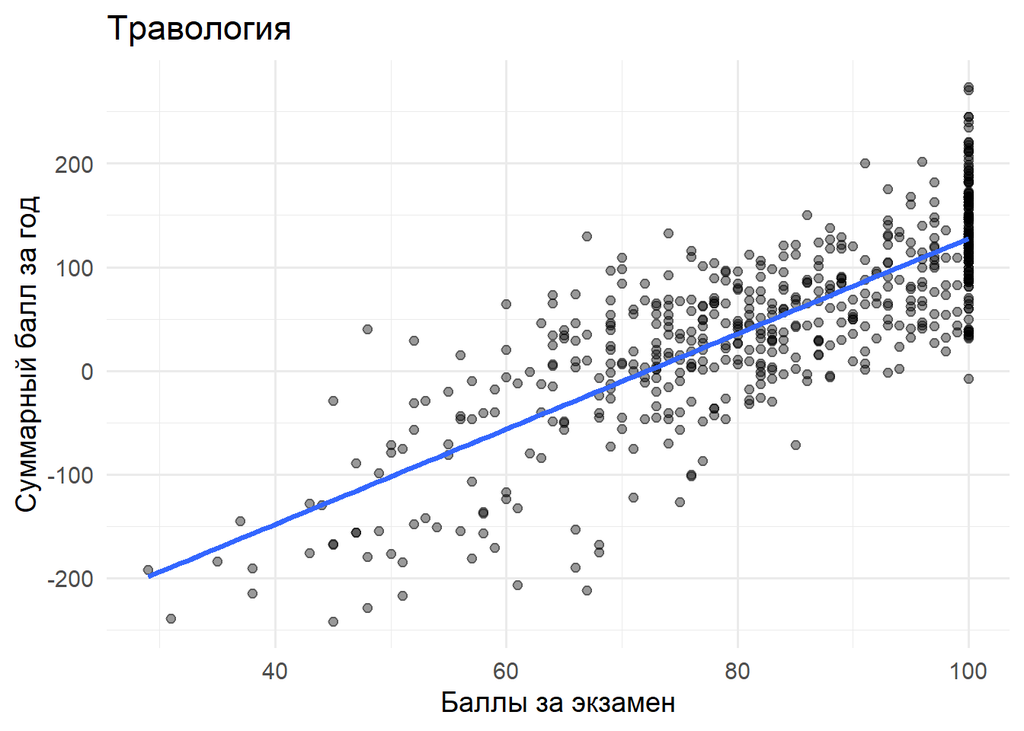

```r
# График 1. Травология
p1 <- ggplot(
  hogwarts,
  aes(x = `Herbology exam`, y = result)
) +
  geom_point(alpha = 0.4) +
  geom_smooth(
    method = "lm",
    formula = y ~ x,
    se = FALSE
  ) +
  labs(
    title = "Травология",
    x = "Баллы за экзамен",
    y = "Суммарный балл за год"
  ) +
  theme_minimal(base_size = 14)

# График 2. Магловедение
p2 <- ggplot(
  hogwarts,
  aes(x = `Muggle studies exam`, y = result)
) +
  geom_point(alpha = 0.4) +
  geom_smooth(
    method = "lm",
    formula = y ~ x,
    se = FALSE
  ) +
  labs(
    title = "Магловедение",
    x = "Баллы за экзамен",
    y = "Суммарный балл за год"
  ) +
  theme_minimal(base_size = 14)

# График 3. Нумерология
p3 <- ggplot(
  hogwarts,
  aes(x = `Arithmancy exam`, y = result)
) +
  geom_point(alpha = 0.4) +
  geom_smooth(
    method = "lm",
    formula = y ~ x,
    se = FALSE
  ) +
  labs(
    title = "Нумерология",
    x = "Баллы за экзамен",
    y = "Суммарный балл за год"
  ) +
  theme_minimal(base_size = 14)

# График 4. Зельеварение
p4 <- ggplot(
  hogwarts,
  aes(x = `Potions exam`, y = result)
) +
  geom_point(alpha = 0.4) +
  geom_smooth(
    method = "lm",
    formula = y ~ x,
    se = FALSE
  ) +
  labs(
    title = "Зельеварение",
    x = "Баллы за экзамен",
    y = "Суммарный балл за год"
  ) +
  theme_minimal(base_size = 14)

p1
```

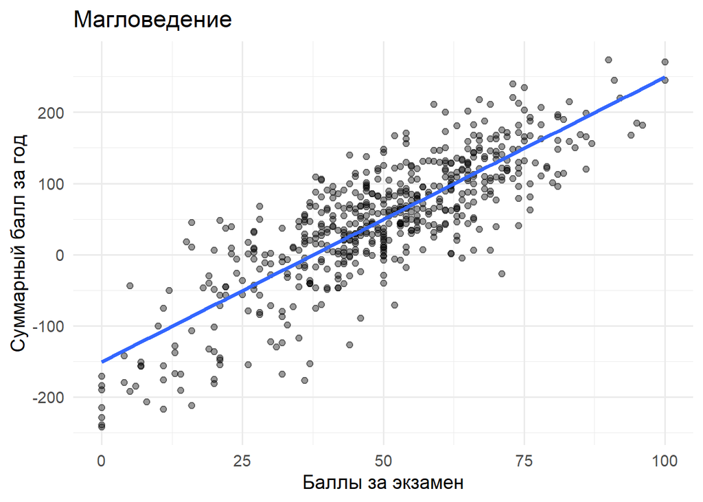

```r
p2
```

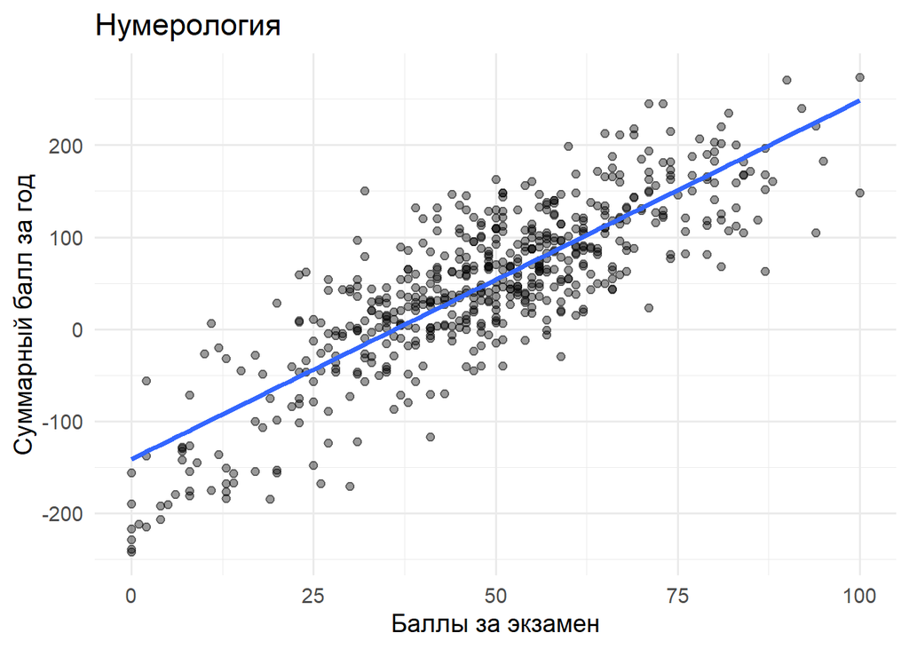

```r
p3
```

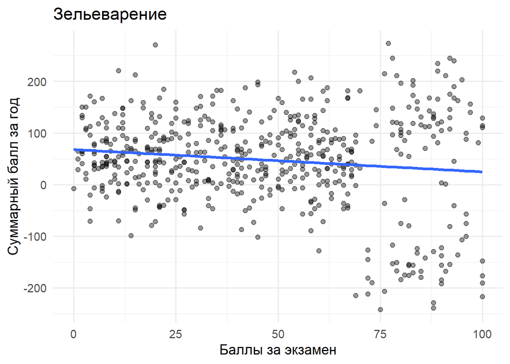

```r
p4
```

**Интерпретация:** По графикам видно, что результаты экзаменов по травологии, магловедению и нумерологии положительно связаны с суммарным баллом за год: чем выше оценка за экзамен, тем выше общий результат. Для зельеварения такой зависимости не наблюдается — линия тренда имеет небольшой отрицательный наклон

*Графики с цветами факультетов*

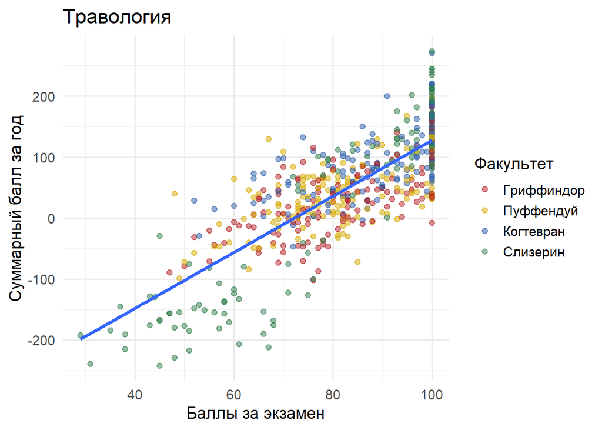

```r
house_colours <- c(
  Gryffindor = "#B32025",
  Hufflepuff = "#D7A900",
  Ravenclaw = "#2E5EAA",
  Slytherin = "#2F7D4A"
)

# График 1. Травология
p1 <- ggplot(
  hogwarts,
  aes(x = `Herbology exam`, y = result)
) +
  geom_point(aes(colour = house), alpha = 0.5) +
  geom_smooth(
    method = "lm",
    formula = y ~ x,
    se = FALSE
  ) +
  scale_colour_manual(
    values = house_colours,
    labels = c(
      Gryffindor = "Гриффиндор",
      Hufflepuff = "Пуффендуй",
      Ravenclaw = "Когтевран",
      Slytherin = "Слизерин"
    )
  ) +
  labs(
    title = "Травология",
    x = "Баллы за экзамен",
    y = "Суммарный балл за год",
    colour = "Факультет"
  ) +
  theme_minimal(base_size = 14)

# График 2. Магловедение
p2 <- ggplot(
  hogwarts,
  aes(x = `Muggle studies exam`, y = result)
) +
  geom_point(aes(colour = house), alpha = 0.5) +
  geom_smooth(
    method = "lm",
    formula = y ~ x,
    se = FALSE
  ) +
  scale_colour_manual(
    values = house_colours,
    labels = c(
      Gryffindor = "Гриффиндор",
      Hufflepuff = "Пуффендуй",
      Ravenclaw = "Когтевран",
      Slytherin = "Слизерин"
    )
  ) +
  labs(
    title = "Магловедение",
    x = "Баллы за экзамен",
    y = "Суммарный балл за год",
    colour = "Факультет"
  ) +
  theme_minimal(base_size = 14)

# График 3. Нумерология
p3 <- ggplot(
  hogwarts,
  aes(x = `Arithmancy exam`, y = result)
) +
  geom_point(aes(colour = house), alpha = 0.5) +
  geom_smooth(
    method = "lm",
    formula = y ~ x,
    se = FALSE
  ) +
  scale_colour_manual(
    values = house_colours,
    labels = c(
      Gryffindor = "Гриффиндор",
      Hufflepuff = "Пуффендуй",
      Ravenclaw = "Когтевран",
      Slytherin = "Слизерин"
    )
  ) +
  labs(
    title = "Нумерология",
    x = "Баллы за экзамен",
    y = "Суммарный балл за год",
    colour = "Факультет"
  ) +
  theme_minimal(base_size = 14)

# График 4. Зельеварение
p4 <- ggplot(
  hogwarts,
  aes(x = `Potions exam`, y = result)
) +
  geom_point(aes(colour = house), alpha = 0.5) +
  geom_smooth(
    method = "lm",
    formula = y ~ x,
    se = FALSE
  ) +
  scale_colour_manual(
    values = house_colours,
    labels = c(
      Gryffindor = "Гриффиндор",
      Hufflepuff = "Пуффендуй",
      Ravenclaw = "Когтевран",
      Slytherin = "Слизерин"
    )
  ) +
  labs(
    title = "Зельеварение",
    x = "Баллы за экзамен",
    y = "Суммарный балл за год",
    colour = "Факультет"
  ) +
  theme_minimal(base_size = 14)

p1
```

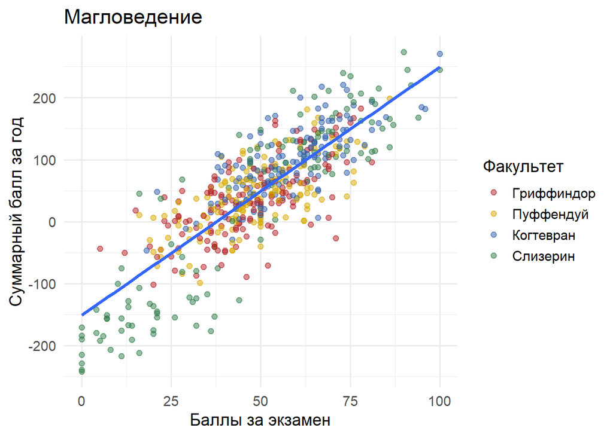

```r
p2
```

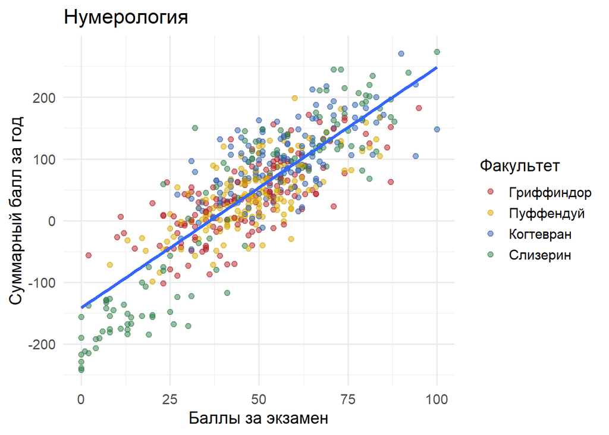

```r
p3
```

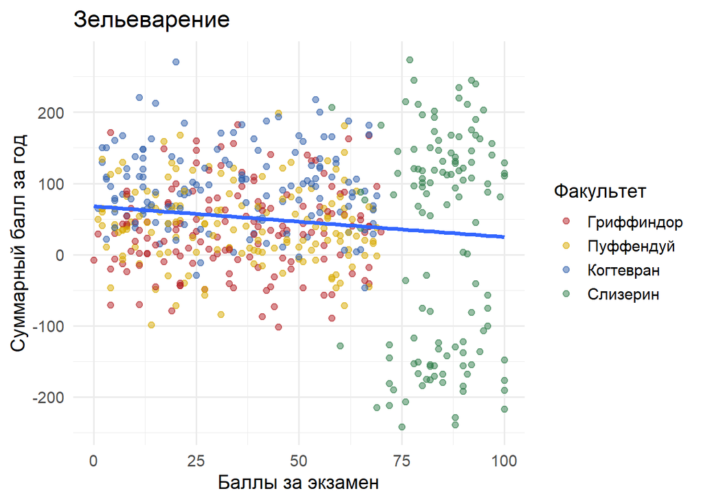

```r
p4
```

**Интерпретация:** После разделения по факультетам становится заметно, что общая отрицательная связь для зельеварения объясняется различиями между факультетами. У Слизерина студенты в среднем набирают больше баллов за экзамен по зельеварению, но их суммарный результат за год ниже. У Когтеврана ситуация обратная: баллы за экзамен по зельеварению в среднем ниже, а суммарный результат за год выше. При этом внутри каждого факультета выраженной связи между оценкой за зельеварение и суммарным результатом практически нет

# Задание 6

Сравните распределение баллов за экзамен по прорицанию и за экзамен по защите от тёмных искусств. Сделайте это тремя разными способами. Под разными способами понимаются идеологически разные геомы или способы группировки. Не считаются разными способами изменения константных визуальных параметров (цвет заливки, размер фигур, другие чисто стилевые отличия) на сходных в остальном графиках.

Объедините графики так, чтобы итоговый график имел два столбца и две строки. Два графика должны стоять в верхней строке и занимать равную площадь. Третий график должен занимать нижнюю строку целиком. Проинтерпретируйте график.

[figure not shown]

```r
# Подготовка данных
exams <- hogwarts |>
  pivot_longer(
    cols = c(
      `Divinations exam`,
      `Defence against the dark arts exam`
    ),
    names_to = "exam",
    values_to = "score"
  ) |>
  mutate(
    exam = recode(
      exam,
      "Divinations exam" = "Прорицание",
      "Defence against the dark arts exam" = "Защита от тёмных искусств"
    ),
    exam = factor(
      exam,
      levels = c("Прорицание", "Защита от тёмных искусств")
    )
  )

# 1. Гистограммы
p_hist <- ggplot(exams, aes(x = score)) +
  geom_histogram(
    bins = 20,
    fill = "#6A8CAF",
    colour = "white"
  ) +
  facet_wrap(vars(exam)) +
  labs(
    x = "Баллы за экзамен",
    y = "Количество студентов"
  ) +
  theme_minimal(base_size = 14)

# 2. График плотности
p_density <- ggplot(exams, aes(x = score, colour = exam)) +
  geom_density(linewidth = 1.2) +
  scale_colour_manual(values = c(
    "Прорицание" = "#2E5EAA",
    "Защита от тёмных искусств" = "#B32025"
  )) +
  labs(
    x = "Баллы за экзамен",
    y = "Плотность",
    colour = "Экзамен"
  ) +
  theme_minimal(base_size = 14)

# 3. Диаграмма размаха
p_box <- ggplot(exams, aes(x = score, y = exam, fill = exam)) +
  geom_boxplot(show.legend = FALSE) +
  scale_fill_manual(values = c(
    "Прорицание" = "#2E5EAA",
    "Защита от тёмных искусств" = "#B32025"
  )) +
  labs(
    x = "Баллы за экзамен",
    y = NULL
  ) +
  theme_minimal(base_size = 14)

# Объединение графиков в одну композицию
p_hist + p_density + p_box +
  plot_layout(
    design = "AB\nCC",
    heights = c(1, 1)
  ) +
  plot_annotation(
    title = "Сравнение результатов экзаменов",
    theme = theme(
      plot.title = element_text(
        size = 20,
        face = "bold",
        hjust = 0.5
      )
    )
  )
```

**Интерпретация:** На экзамене по прорицанию большинство студентов набрали мало баллов. Медиана составила 13 баллов. По защите от тёмных искусств результаты выше: медиана — 50 баллов, а оценки распределены по более широкому диапазону. Таким образом, студенты в целом лучше справились с защитой от тёмных искусств, чем с прорицанием

# Задание 7

Постройте диаграмму рассеяния (скаттерплот), где по осям отложены результаты экзаменов по заклинаниям и по древним рунам. На графике есть некоторая проблема. Если вам трудно её определить, возьмите подсказку: постройте скаттерплот по данным из файла `data/podskazka.csv`. По оси x отложите переменную `y`, по оси y — переменную `x`, а пределы оси y задайте от 200 до 500. Предложите и подкрепите визуализациями не менее трёх способов решить эту проблему.

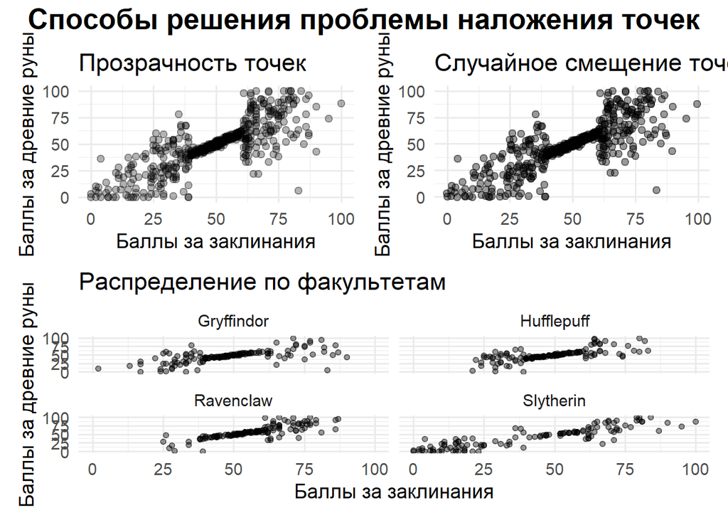

```r
# 1. Решение с помощью прозрачности
p_alpha <- ggplot(
  hogwarts,
  aes(x = `Charms exam`, y = `Study of ancient runes exam`)
) +
  geom_point(alpha = 0.3, size = 2) +
  labs(
    title = "Прозрачность точек",
    x = "Баллы за заклинания",
    y = "Баллы за древние руны"
  ) +
  theme_minimal(base_size = 14)


# 2. Решение с помощью случайного смещения

p_jitter <- ggplot(
  hogwarts,
  aes(x = `Charms exam`, y = `Study of ancient runes exam`)
) +
  geom_jitter(
    width = 0.5,
    height = 0.5,
    alpha = 0.4,
    size = 2
  ) +
  labs(
    title = "Случайное смещение точек",
    x = "Баллы за заклинания",
    y = "Баллы за древние руны"
  ) +
  theme_minimal(base_size = 14)

# 3. Разделение графиков по факультетам
p_facets <- ggplot(
  hogwarts,
  aes(x = `Charms exam`, y = `Study of ancient runes exam`)
) +
  geom_point(alpha = 0.4, size = 1.5) +
  facet_wrap(vars(house)) +
  labs(
    title = "Распределение по факультетам",
    x = "Баллы за заклинания",
    y = "Баллы за древние руны"
  ) +
  theme_minimal(base_size = 14)

# Объединение графиков
p_alpha + p_jitter + p_facets +
  plot_layout(
    design = "AB\nCC"
  ) +
  plot_annotation(
    title = "Способы решения проблемы наложения точек",
    theme = theme(
      plot.title = element_text(
        size = 20,
        face = "bold",
        hjust = 0.5
      )
    )
  )
```

**Проблема и способы её решения:** На исходном графике часть точек накладывается друг на друга, поэтому не все наблюдения хорошо видны. Прозрачность помогает увидеть скопления точек, случайное смещение позволяет рассмотреть совпадающие значения, а разделение по факультетам делает графики менее загруженными. Все три способа помогают лучше рассмотреть распределение оценок и связь между результатами двух экзаменов

# Задание 8

Используйте таблицу с баллами по неделям для первых 30 студентов, которую мы получили на занятии (`first_30`, конспект 2, раздел «Линии: `group`, спагетти, акцент, профиль (слайд 53)»). В ней пока нет столбца `bloodStatus`, а он понадобится для подписей. Постройте лайнплоты для всех студентов. Выделите при помощи пакета gghighlight студентов факультета Рейвенкло, на лейблах отразите их происхождение.

Линии студентов других факультетов покрасьте в нейтральный серый цвет и задайте его явно, а их толщину сделайте не больше трети стандартной. Проинтерпретируйте график.

```r
# Подготовка данных — код из лекции
weeks_long <- hogwarts |>
  select(id, house, starts_with("week_")) |>
  pivot_longer(
    cols = starts_with("week_"),
    names_to = "week",
    values_to = "points"
  ) |>
  mutate(week = parse_number(week))

first_30 <- weeks_long |> filter(id <= 30)
student_30 <- weeks_long |> filter(id == 30)

weeks_long
```

```
# A tibble: 22,400 × 4
      id house      week points
   <dbl> <chr>     <dbl>  <dbl>
 1     1 Slytherin     1      0
 2     1 Slytherin     2     -5
 3     1 Slytherin     3      0
 4     1 Slytherin     4      9
 5     1 Slytherin     5      4
 6     1 Slytherin     6    -17
 7     1 Slytherin     7      9
 8     1 Slytherin     8      7
 9     1 Slytherin     9     -5
10     1 Slytherin    10     15
# ℹ 22,390 more rows
```

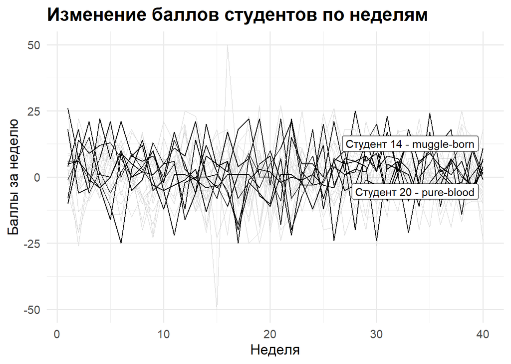

```r
# Добавляем информацию о происхождении студентов
first_30 <- first_30 |>
  left_join(
    hogwarts |> select(id, bloodStatus),
    by = "id"
  ) |>
  mutate(
    student_label = paste("Студент", id, "-", bloodStatus)
  )

# Строим график
ggplot(
  first_30,
  aes(x = week, y = points, group = id)
) +
  geom_line(linewidth = 0.5) +
  gghighlight(
    house == "Ravenclaw",
    label_key = student_label,
    use_group_by = FALSE,
    unhighlighted_params = list(
      colour = "grey82",
      linewidth = 0.15
    ),
    calculate_per_facet = TRUE
  ) +
  labs(
    title = "Изменение баллов студентов по неделям",
    x = "Неделя",
    y = "Баллы за неделю"
  ) +
  theme_minimal(base_size = 14) +
  theme(
    plot.title = element_text(size = 18, face = "bold")
  )
```

**Интерпретация:** На графике тёмными линиями выделены студенты Когтеврана, а остальные студенты показаны светло-серыми линиями. Видно, что баллы меняются от недели к неделе: у одних студентов они растут, у других падают. При этом даже у студентов Когтеврана результаты сильно различаются. Общей тенденции к росту или снижению баллов не наблюдается

# Задание 9

Подробно (останавливаясь на каждом пункте, а не в общем) опишите, какие стороны графика и интерпретации (она приводится ниже) вы считаете верными и сделанными в соответствии с хорошими практиками, а какие — нет. Сделайте свой график, который отвечает на тот же исследовательский вопрос, но лишён технических и интерпретационных недостатков оригинала (если вы таковые нашли и упомянули).

Интерпретация графика:

> В ходе исследования, проведенного в ФГБОУССО «Хогвартс» (далее Хогвартс) для оценки успешности образовательного процесса и психоэмоционального состояния участников вышеназванного процесса, были выявлены тревожные закономерности. А именно — при оценке среднего балла, полученного в течение недели совокупностью учащихся Хогвартса, была выявлена тенденция к резкому снижению данного показателя с течением времени. Так, в начале учебного процесса студенты набирали в среднем 2 балла (максимальный показатель). В последующие недели балл достоверно снижался, достигая минимальных значений к концу года (см. рис. 1). Мы полагаем, что данный процесс связан с ухудшением психологического состояния преподавателей означенного учебного заведения. Таким образом, в течение года они от мотивирующих мер положительного характера (добавление баллов за правильные ответы на занятиях и успехи во внеучебной деятельности) переходят к репрессивным действиям (учащающийся и увеличивающийся по модулю отъем баллов факультета за предполагаемые нарушения дисциплины, недостаточную, по мнению преподавателя, подготовку к занятию и пр.). Это вызывает снижение у учащихся мотивации к получению знаний, что вызывает следующий шаг снижения средненедельного балла — т.о., поведение педагогов вызывает своего рода circulus vitiosus.

> По итогам исследования и с учетом полученных результатов предлагается следующее: произвести замену профессорско-преподавательского состава с заменой педагогов, наиболее подверженных выгоранию в течение года (проявляющемуся в виде систематического снижения баллов студентам). Издать декрет о недопущении избыточного штрафования учащихся, начиная с 18-й недели учебного процесса до конца года. К нарушителям применять взыскания материально-магического характера. Объявить выговор с занесением в личное дело текущим представителям руководящего состава Хогвартса (далее дирекция).

### Разбор интерпретации

1. В начале автор пишет, что исследование проводилось для оценки успеваемости и психологического состояния участников. Но в данных есть только баллы студентов, информации о психологическом состоянии нет.
2. Автор утверждает, что средний балл резко снижается со временем. Однако значения не падают каждую неделю, а меняются. Поэтому говорить о постоянном снижении неправильно.
3. Утверждение, что в начале года средний балл составлял 2, неверно. На первой неделе он примерно 1,5, а максимальное значение наблюдается на 14-й неделе.
4. Автор пишет, что баллы достоверно снижались, но никаких статистических проверок не приводит. По одному графику нельзя сделать вывод о статистической значимости.
5. Также автор утверждает, что минимальные значения наблюдаются к концу года. На самом деле самое низкое среднее значение приходится на 21-ю неделю.
6. Автор связывает снижение баллов с ухудшением психологического состояния преподавателей. Но в данных нет информации о преподавателях, поэтому подтвердить такую связь нельзя.
7. Далее говорится, что преподаватели постепенно переходят от поощрений к штрафам. Однако данных о том, как именно преподаватели начисляли и снимали баллы, в исследовании нет.
8. Автор предполагает, что штрафы снижают мотивацию студентов и из-за этого баллы продолжают падать. Но информации о мотивации студентов тоже нет, поэтому подтвердить такую связь невозможно.
9. В конце автор предлагает заменить преподавателей, запретить избыточные штрафы с 18-й недели, наказать нарушителей и объявить выговор руководству. Такие рекомендации не обоснованы результатами исследования, поскольку причины изменения баллов не установлены.

В целом в интерпретации правильно выбрана сама тема — посмотреть, как меняется средний балл студентов по неделям. Но многие выводы автора не подтверждаются данными. По ним можно описать изменение баллов, но нельзя установить, почему оно происходит.

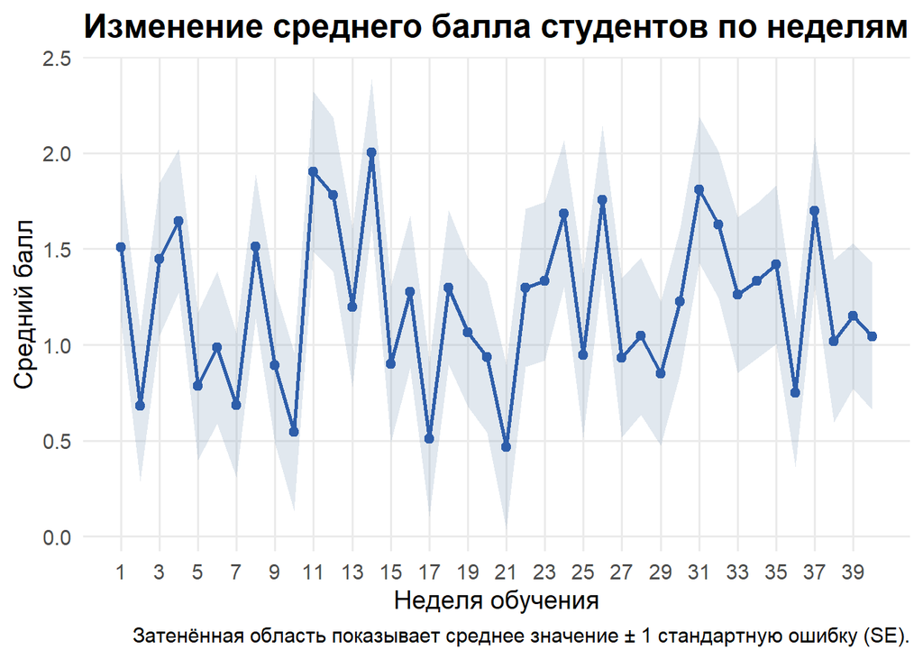

```r
# Подготовка данных
weekly_scores <- hogwarts |>
  pivot_longer(
    cols = starts_with("week_"),
    names_to = "week",
    values_to = "points"
  ) |>
  mutate(week = parse_number(week)) |>
  group_by(week) |>
  summarise(
    mean_points = mean(points, na.rm = TRUE),
    se = sd(points, na.rm = TRUE) / sqrt(sum(!is.na(points)))
  )

# Построение графика
ggplot(weekly_scores, aes(x = week, y = mean_points)) +
  geom_ribbon(
    aes(
      ymin = mean_points - se,
      ymax = mean_points + se
    ),
    fill = "#6A8CAF",
    alpha = 0.2
  ) +
  geom_line(
    colour = "#2E5EAA",
    linewidth = 1
  ) +
  geom_point(
    colour = "#2E5EAA",
    size = 2
  ) +
  scale_x_continuous(breaks = seq(1, 40, by = 2)) +
  labs(
    title = "Изменение среднего балла студентов по неделям",
    x = "Неделя обучения",
    y = "Средний балл",
    caption = "Затенённая область показывает среднее значение ± 1 стандартную ошибку (SE)."
  ) +
  theme_minimal(base_size = 14) +
  theme(
    plot.title = element_text(size = 18, face = "bold"),
    panel.grid.minor = element_blank()
  )
```

Средний балл студентов заметно меняется от недели к неделе. При этом устойчивой тенденции к снижению на протяжении учебного года не наблюдается. Самые высокие средние значения встречаются в первой половине года, а во второй половине баллы продолжают колебаться

# Задание 10 (дополнительное)

Воспроизведите график максимально близко к оригиналу и проинтерпретируйте его. Постарайтесь максимально точно отразить каждый элемент.